# Assignment 2

Kimberly Juarez-Rico

9/26/2020

This assignment focused on performing equity analysis by using Census, American Communities Survey (ACS), and Public Use Microdata (PUMS) data. Survey data from censusapi comes in “buckets” or different catergories for grouping together data on a larger scale. For example, the buckets for different income levels sometimes range from $30k - $40k. However, PUMS allows for data to be analyzed on a smaller scale at the household or even individual level. For this assignment, ACS 5 year and 1 year data and 5 year PUMS were used to analyze different factors that affect education and educational outcomes.

For this assignment, I chose to focus on Sonoma County when for parts 1 and 3 that specified that the analysis could focus on just one Bay Area county in particular. Part 2 asked for an analysis on the entire Bay Area. I chose Sonoma County because I grew up there so I am interested in analyzing the data from this area.

Part 1: The first part of the assignment was to create an analysis on educational attainment by race in the county of choice. I used ACS C15002 data which groups together educational attainment by race and sex. I had to use C15002 data because this was one the only data set that included race into the analysis of educational attainment.

First, the necessary packages were installed that would make it easier to use the ACS and Census data:

Census data was downloaded onto my computer:

This chuck creates a data set that calculates the total number of people surveyed for the 15002 data set so that it can then be used to manipulate the data set in C15002.

```
## # A tibble: 1 x 1
##    total
##    <dbl>
## 1 715936
```

Specific race labels were created according to the corresponding data group. C15002 is divided by race in that a letter of the alphabet is added to the end of the title to distinguish between racial groups:

```
## # A tibble: 90 x 7
##    county estimate sex    race         total percentageOfPop na.rm
##    <chr>     <dbl> <chr>  <chr>        <dbl>           <dbl> <lgl>
##  1 097      135408 Male   White Alone 715936           18.9  TRUE
##  2 097       11888 Male   White Alone 715936            1.66 TRUE
##  3 097       26187 Male   White Alone 715936            3.66 TRUE
##  4 097       46045 Male   White Alone 715936            6.43 TRUE
##  5 097       51288 Male   White Alone 715936            7.16 TRUE
##  6 097      148869 Female White Alone 715936           20.8  TRUE
##  7 097       10042 Female White Alone 715936            1.40 TRUE
##  8 097       25526 Female White Alone 715936            3.57 TRUE
##  9 097       54851 Female White Alone 715936            7.66 TRUE
## 10 097       58450 Female White Alone 715936            8.16 TRUE
## # ... with 80 more rows
```

This creates a bar graph of educational attainment by race for people living in Sonoma County over 25 years old:

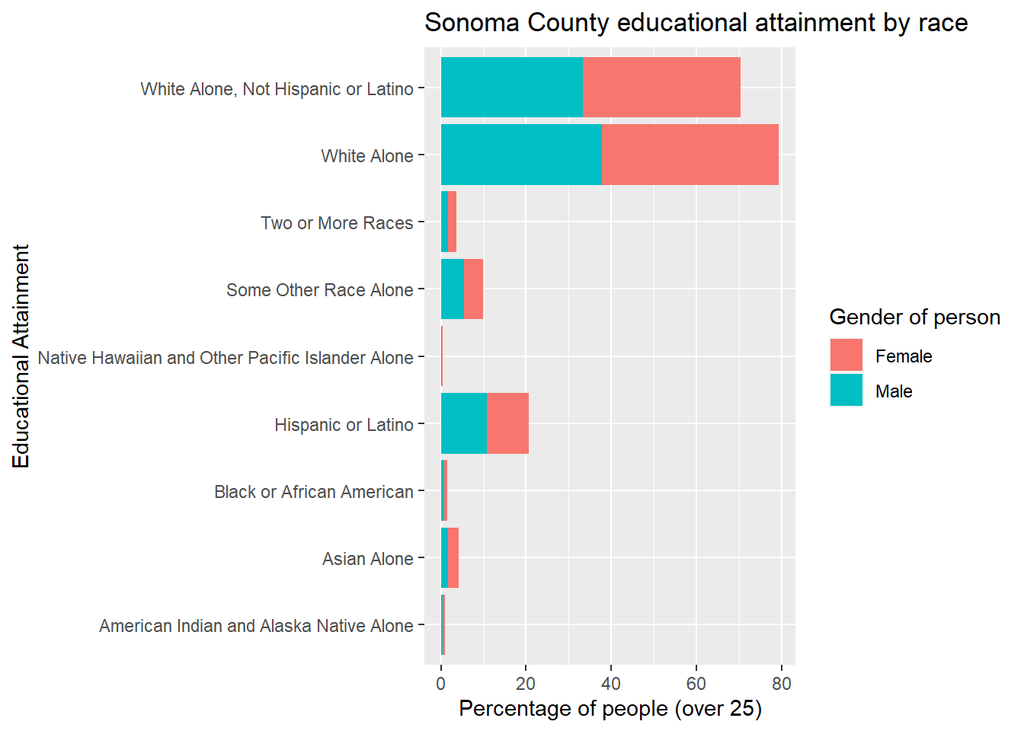

The percentage of the population that has the highest percentage of educational attainment are White and White (non-Hispanic).

Part 2: Estimating the number and percentage of K-12 students that do not have internet access at home using PUMS data.

Load in the PUMS 2018 data:

Categorize PUMS data so that the only data sets presented are the number of households with or without access to the internet and number of persons under the age of 18 in each household:

[output not shown]

[output not shown]

[output not shown]

[output not shown]

[output not shown]

[output not shown]

[output not shown]

[output not shown]

[output not shown]

[output not shown]

[output not shown]

[output not shown]

[output not shown]

[output not shown]